# Weight Lifting Classification

M Hamersma

14 April 2020

### Introduction

This is a HAR (Human Activity Recognition) model. The objective is to analyse the x, y and z direction movement data captured from wearable fitness devices while doing bicep curls with a 1.25kg dumbell, and classify new exercises as having been done correctly or not. Data and concept is from Ugulino, W.; Cardador, D.; Vega, K.; Velloso, E.; Milidiu, R.; Fuks, H. Wearable Computing: Accelerometers’ Data Classification of Body Postures and Movements.

Read more: http://groupware.les.inf.puc-rio.br/work.jsf?p1=10335#ixzz6JZBFyhzW

## Prepare the environment

```r
setwd("~/R/PML/Project")
library(caret)
```

```r
library(readr)
library(corrplot)
library(rattle)
library(rpart)
library(rpart.plot)
library(randomForest)
```

## Loading Data

The data was downloaded to two csv files:

```r
training <- read.csv("pml-training1.csv", sep = ";", na.strings = c("NA", "#DIV/0!", ""))
testing <- read.csv("pml-testing1.csv", sep = ";", na.strings = c("NA", "#DIV/0!", ""))

dim(training)
```

```
## [1] 19622   160
```

```r
dim(testing)
```

```
## [1]  20 160
```

## Tidying up

The data contains many NA and near zero variables. Due to the nature of the Machine Learning algorithms, the amount of data, and the fact that the exercises has already been classified, there is no need to dig too deep - rather focus on detecting the variables that influence the classification.

# The first five columns are just name identfiers and can be removed.

```r
names(training[, 1:5])
```

```
## [1] "X"                    "user_name"            "raw_timestamp_part_1"
## [4] "raw_timestamp_part_2" "cvtd_timestamp"
```

```r
training <- training[, -(1:5)]
dim(training)
```

```
## [1] 19622   155
```

# Remove variables from training with near zero variance, using the train set as reference

```r
NearZV <- nearZeroVar(training)
training <- training[, -NearZV]
dim(training)
```

```
## [1] 19622   119
```

# remove variables that are mostly NA

```r
AllNA    <- sapply(training, function(x) mean(is.na(x))) > 0.95
training <- training[, AllNA==FALSE]
dim(training)
```

```
## [1] 19622    54
```

# Divide the training data into a train and validation set

```r
set.seed(100)
inTrain  <- createDataPartition(training$classe, p=0.75, list=FALSE)
Train <- training[inTrain, ]
Validate  <- training[-inTrain, ]
dim(Train)
```

```
## [1] 14718    54
```

```r
dim(Validate)
```

```
## [1] 4904   54
```

# Inter-variable correlation

If too many variables in the training model correlate it can be confusing without contributing anything.

```r
corMatrix <- cor(Train[, -54])
```

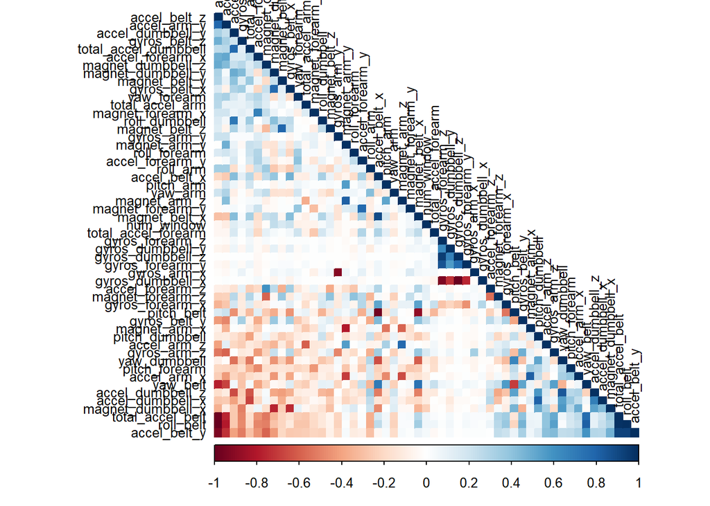

There are not many that correlate, so we can proceed with classifier modelling. The models of to choose are Random Forests, Decision Tree and Gradient Boost models. The one with the best Accuracy will be chosen for the Test excercise.

# Random Forest

```r
set.seed(100)
controlRF <- trainControl(method="cv", number=3, verboseIter=FALSE)
modFitRandForest <- train(classe ~ ., data=Train, method="rf",
                          trControl=controlRF)
modFitRandForest$finalModel
```

```
##
## Call:
##  randomForest(x = x, y = y, mtry = param$mtry)
##                Type of random forest: classification
##                      Number of trees: 500
## No. of variables tried at each split: 27
##
##         OOB estimate of  error rate: 0.22%
## Confusion matrix:
##      A    B    C    D    E  class.error
## A 4181    4    0    0    0 0.0009557945
## B    5 2839    3    1    0 0.0031601124
## C    0    3 2563    1    0 0.0015582392
## D    0    0   13 2398    1 0.0058043118
## E    0    0    0    2 2704 0.0007390983
```

Validate against the Validation Set:

```r
predictRandForest <- predict(modFitRandForest, newdata=Validate)
confMatRandForest <- confusionMatrix(predictRandForest, Validate$classe)
confMatRandForest
```

```
## Confusion Matrix and Statistics
##
##           Reference
## Prediction    A    B    C    D    E
##          A 1395    0    0    0    0
##          B    0  949    2    0    0
##          C    0    0  853    3    0
##          D    0    0    0  801    0
##          E    0    0    0    0  901
##
## Overall Statistics
##
##                Accuracy : 0.999
##                  95% CI : (0.9976, 0.9997)
##     No Information Rate : 0.2845
##     P-Value [Acc > NIR] : < 2.2e-16
##
##                   Kappa : 0.9987
##
##  Mcnemar's Test P-Value : NA
##
## Statistics by Class:
##
##                      Class: A Class: B Class: C Class: D Class: E
## Sensitivity            1.0000   1.0000   0.9977   0.9963   1.0000
## Specificity            1.0000   0.9995   0.9993   1.0000   1.0000
## Pos Pred Value         1.0000   0.9979   0.9965   1.0000   1.0000
## Neg Pred Value         1.0000   1.0000   0.9995   0.9993   1.0000
## Prevalence             0.2845   0.1935   0.1743   0.1639   0.1837
## Detection Rate         0.2845   0.1935   0.1739   0.1633   0.1837
## Detection Prevalence   0.2845   0.1939   0.1746   0.1633   0.1837
## Balanced Accuracy      1.0000   0.9997   0.9985   0.9981   1.0000
```

Random Forest Validation Results = : ** 0.999**

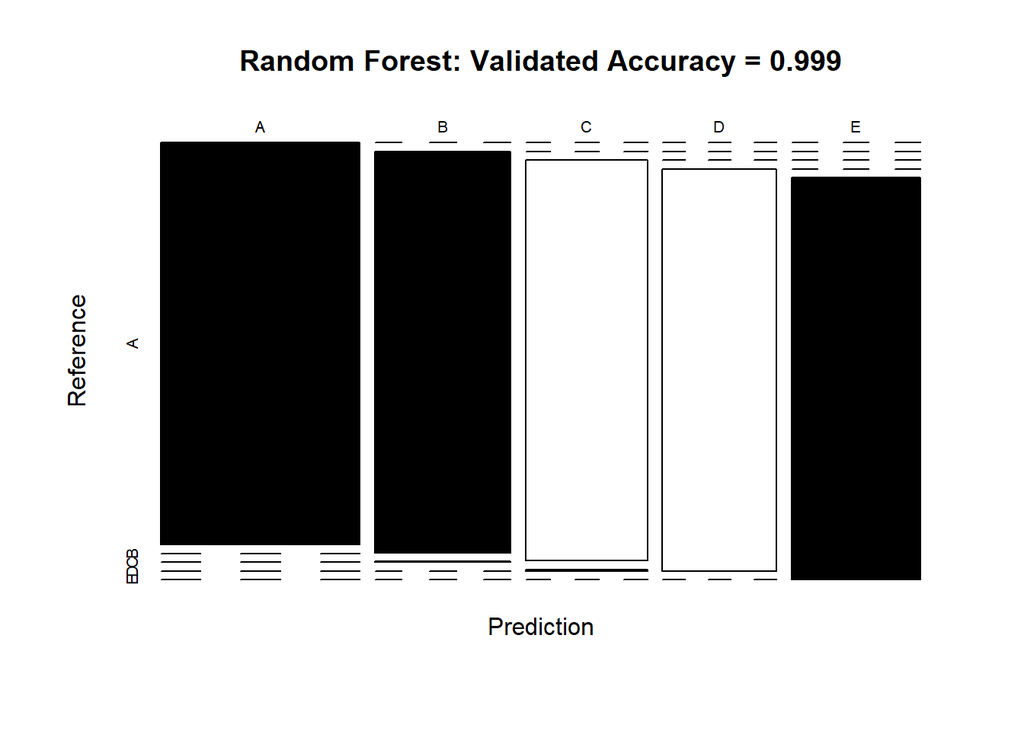

# Decision Tree model

[figure not shown]

```r
set.seed(100)
modFitDecTree <- rpart(classe ~ ., data=Train, method="class")
fancyRpartPlot(modFitDecTree)
```

Valdidate against Validate data set:

```r
predictDecTree <- predict(modFitDecTree, newdata=Validate, type="class")
confMatDecTree <- confusionMatrix(predictDecTree, Validate$classe)
confMatDecTree
```

```
## Confusion Matrix and Statistics
##
##           Reference
## Prediction    A    B    C    D    E
##          A 1247  209   36   68   23
##          B   29  530   57   30   34
##          C   17   65  678  112   73
##          D   77  117   62  514  118
##          E   25   28   22   80  653
##
## Overall Statistics
##
##                Accuracy : 0.7386
##                  95% CI : (0.726, 0.7508)
##     No Information Rate : 0.2845
##     P-Value [Acc > NIR] : < 2.2e-16
##
##                   Kappa : 0.6682
##
##  Mcnemar's Test P-Value : < 2.2e-16
##
## Statistics by Class:
##
##                      Class: A Class: B Class: C Class: D Class: E
## Sensitivity            0.8939   0.5585   0.7930   0.6393   0.7248
## Specificity            0.9042   0.9621   0.9341   0.9088   0.9613
## Pos Pred Value         0.7877   0.7794   0.7175   0.5788   0.8082
## Neg Pred Value         0.9554   0.9008   0.9553   0.9278   0.9395
## Prevalence             0.2845   0.1935   0.1743   0.1639   0.1837
## Detection Rate         0.2543   0.1081   0.1383   0.1048   0.1332
## Detection Prevalence   0.3228   0.1387   0.1927   0.1811   0.1648
## Balanced Accuracy      0.8991   0.7603   0.8635   0.7740   0.8430
```

Decision Tree Accuracy = ** 0.7386 **

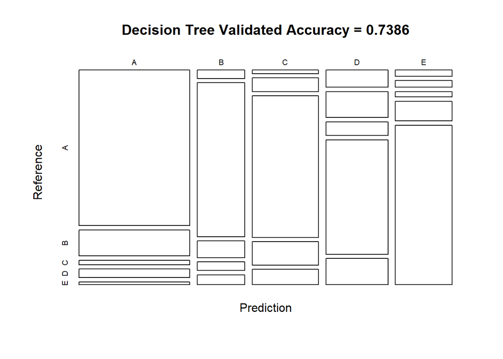

# Boost model

```r
set.seed(100)
controlGBM <- trainControl(method = "repeatedcv", number = 5, repeats = 1)
modFitGBM  <- train(classe ~ ., data=Train, method = "gbm",
                    trControl = controlGBM, verbose = FALSE)
modFitGBM$finalModel
```

```
## A gradient boosted model with multinomial loss function.
## 150 iterations were performed.
## There were 53 predictors of which 53 had non-zero influence.
```

Valdiation on Validate dataset

```r
predictGBM <- predict(modFitGBM, newdata=Validate)
confMatGBM <- confusionMatrix(predictGBM, Validate$classe)
confMatGBM
```

```
## Confusion Matrix and Statistics
##
##           Reference
## Prediction    A    B    C    D    E
##          A 1392    9    0    0    0
##          B    3  933    8    2    1
##          C    0    7  846    8    0
##          D    0    0    1  794    3
##          E    0    0    0    0  897
##
## Overall Statistics
##
##                Accuracy : 0.9914
##                  95% CI : (0.9884, 0.9938)
##     No Information Rate : 0.2845
##     P-Value [Acc > NIR] : < 2.2e-16
##
##                   Kappa : 0.9892
##
##  Mcnemar's Test P-Value : NA
##
## Statistics by Class:
##
##                      Class: A Class: B Class: C Class: D Class: E
## Sensitivity            0.9978   0.9831   0.9895   0.9876   0.9956
## Specificity            0.9974   0.9965   0.9963   0.9990   1.0000
## Pos Pred Value         0.9936   0.9852   0.9826   0.9950   1.0000
## Neg Pred Value         0.9991   0.9960   0.9978   0.9976   0.9990
## Prevalence             0.2845   0.1935   0.1743   0.1639   0.1837
## Detection Rate         0.2838   0.1903   0.1725   0.1619   0.1829
## Detection Prevalence   0.2857   0.1931   0.1756   0.1627   0.1829
## Balanced Accuracy      0.9976   0.9898   0.9929   0.9933   0.9978
```

GBM Model Accurcay : ** 0.9914

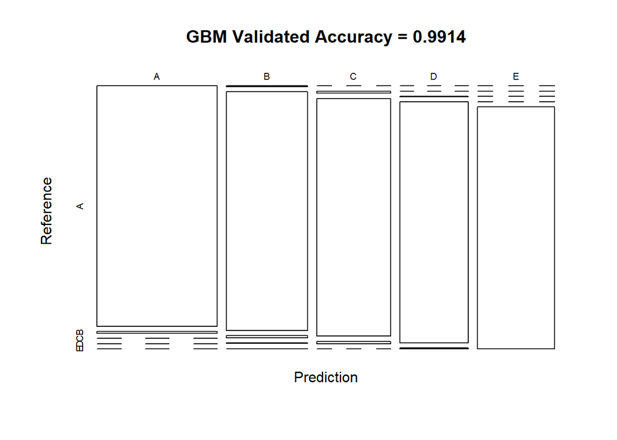

## Choose the best model:

Random Forest Accuracy: **0.999** Decision Tree Accuracy: ** 0.7386 **Gradient Boost Accuracy:** 0.9914 **

## Run against Test data 20 records

```r
predictTEST <- predict(modFitRandForest, newdata=testing)
predictTEST
```

```
##  [1] B A B A A E D B A A B C B A E E A B B B
## Levels: A B C D E
```